# Scale Development and Validation: An Application of EFA and CFA

2025-04-16

Part I.Exploratory Factor Analysis (EFA) Step 0: Data Preparation

```r
options(scipen = 100)
library(psych)
library(readxl)
data.raw <- read.csv("~/Desktop/DT_data.csv")
str(data.raw)
```

```
## 'data.frame':    297 obs. of  33 variables:
##  $ ID    : int  1 2 3 4 5 6 7 8 9 10 ...
##  $ School: chr  "HSJH" "HSJH" "HSJH" "HSJH" ...
##  $ Grade : int  8 8 8 8 8 8 8 9 9 9 ...
##  $ Birth : num  99 99 99 98.1 98.1 ...
##  $ Sex   : int  1 1 0 0 1 0 0 1 1 1 ...
##  $ X1    : int  6 4 4 4 6 4 3 6 3 6 ...
##  $ X2    : int  1 3 6 6 4 4 4 4 2 4 ...
##  $ X3    : int  3 3 5 4 6 4 4 5 5 3 ...
##  $ X4    : int  5 4 6 4 4 4 4 5 5 4 ...
##  $ X5    : int  4 3 5 4 6 4 4 5 5 5 ...
##  $ X6    : int  2 3 4 4 4 4 3 2 3 4 ...
##  $ X7    : int  1 3 1 3 5 3 4 1 1 4 ...
##  $ X8    : int  1 3 1 3 1 4 3 4 1 1 ...
##  $ X9    : int  1 3 4 3 1 4 4 5 1 3 ...
```

[output cut: 19 more lines]

Step 1: Create a DataFrame Containing Only X1 to X28

```r
d1 <- data.raw[ , c(6:33)]
d1
```

```
##     X1 X2 X3 X4 X5 X6 X7 X8 X9 X10 X11 X12 X13 X14 X15 X16 X17 X18 X19 X20 X21
## 1    6  1  3  5  4  2  1  1  1   4   3   3   3   3   3   4   3   2   1   1   1
## 2    4  3  3  4  3  3  3  3  3   3   3   4   4   6   2   2   2   2   2   5   3
## 3    4  6  5  6  5  4  1  1  4   1   1   2   3   6   6   1   6   4   6   6   4
## 4    4  6  4  4  4  4  3  3  3   3   3   3   3   4   4   4   4   4   4   3   4
## 5    6  4  6  4  6  4  5  1  1   3   3   3   1   1   1   6   1   1   1   1   1
## 6    4  4  4  4  4  4  3  4  4   4   4   4   3   4   4   3   4   4   1   3   4
## 7    3  4  4  4  4  3  4  3  4   4   4   4   4   3   4   4   4   3   4   4   4
## 8    6  4  5  5  5  2  1  4  5   5   4   3   4   3   4   2   1   2   1   1   1
## 9    3  2  5  5  5  3  1  1  1   2   1   1   1   2   1   1   1   1   1   1   1
## 10   6  4  3  4  5  4  4  1  3   3   3   3   4   3   3   3   5   4   1   5   3
## 11   6  6  4  6  6  6  6  4  6   4   4   5   3   5   3   6   3   6   1   5   2
## 12   6  4  6  6  6  1  3  1  1   1   1   1   1   1   4   6   4   4   1   6   1
## 13   5  4  4  5  5  4  2  1  1   1   1   1   1   1   5   6   4   4   1   4   1
## 14   5  4  3  3  4  3  4  4  3   3   4   4   3   3   2   4   2   3   1   2   3
```

[output cut: 581 more lines]

```r
describeBy(d1)
```

```
##     vars   n mean   sd median trimmed  mad min max range  skew kurtosis   se
## X1     1 297 4.22 1.54      4    4.36 1.48   1   6     5 -0.54    -0.67 0.09
## X2     2 297 3.72 1.44      4    3.77 1.48   1   6     5 -0.22    -0.64 0.08
## X3     3 296 4.33 1.31      4    4.45 1.48   1   6     5 -0.58    -0.25 0.08
## X4     4 297 4.30 1.33      4    4.43 1.48   1   6     5 -0.61    -0.02 0.08
## X5     5 297 4.53 1.29      5    4.67 1.48   1   6     5 -0.72     0.18 0.07
## X6     6 296 3.15 1.36      3    3.13 1.48   1   6     5  0.01    -0.64 0.08
## X7     7 297 3.31 1.54      3    3.27 1.48   1   6     5  0.03    -0.96 0.09
## X8     8 296 2.57 1.37      3    2.45 1.48   1   6     5  0.45    -0.69 0.08
## X9     9 296 3.08 1.42      3    3.03 1.48   1   6     5  0.21    -0.71 0.08
## X10   10 296 2.68 1.35      3    2.56 1.48   1   6     5  0.45    -0.53 0.08
## X11   11 296 2.81 1.38      3    2.72 1.48   1   6     5  0.28    -0.69 0.08
## X12   12 297 3.19 1.43      3    3.17 1.48   1   6     5 -0.02    -0.83 0.08
## X13   13 297 2.86 1.47      3    2.76 1.48   1   6     5  0.34    -0.76 0.09
## X14   14 296 2.33 1.28      2    2.19 1.48   1   6     5  0.79     0.05 0.07
## X15   15 295 2.68 1.54      2    2.51 1.48   1   6     5  0.60    -0.64 0.09
## X16   16 297 2.72 1.37      3    2.60 1.48   1   6     5  0.50    -0.41 0.08
## X17   17 296 2.47 1.35      2    2.33 1.48   1   6     5  0.64    -0.31 0.08
## X18   18 295 3.64 1.35      4    3.69 1.48   1   6     5 -0.31    -0.48 0.08
## X19   19 296 1.62 1.13      1    1.37 0.00   1   6     5  1.89     3.04 0.07
## X20   20 294 2.53 1.51      2    2.37 1.48   1   6     5  0.54    -0.88 0.09
## X21   21 296 2.73 1.51      3    2.61 1.48   1   6     5  0.44    -0.82 0.09
## X22   22 293 2.27 1.53      2    2.01 1.48   1   6     5  1.01    -0.08 0.09
## X23   23 297 2.20 1.48      2    1.95 1.48   1   6     5  1.13     0.29 0.09
## X24   24 297 2.01 1.29      1    1.80 0.00   1   6     5  1.14     0.44 0.07
## X25   25 296 1.87 1.34      1    1.61 0.00   1   6     5  1.58     1.72 0.08
## X26   26 296 2.66 1.68      2    2.46 1.48   1   6     5  0.65    -0.86 0.10
## X27   27 297 1.41 0.90      1    1.18 0.00   1   6     5  2.44     6.05 0.05
## X28   28 297 3.51 1.88      4    3.51 2.97   1   6     5 -0.06    -1.46 0.11
```

```r
d1$totscore<-rowSums(d1[1:28])
d1$totscore
```

```
##   [1]  67  77 109  95  67  94 105  79  49  89 115  76  71  84  33  90  71  76
##  [19]  90  60  89  89  58  96  83  88  NA  80  92  93 101  35  76  NA  81 123
##  [37]  70  75  93  91  91  92  83  77 113  98 106  NA  76  88  56  NA 101  84
##  [55]  89  96  63  85 110  66 115  84  73  57  83  78  NA  66  87  86 101  88
##  [73]  78  94  70 103  73 114  74  86  90  95  90  46  70  87 102  95  85  37
##  [91]  58  70 102 105  NA  70 102  74  77  80  NA  81  98  67  NA  71 107  85
## [109]  96  87  48  86  81 100  63  28  74  83  95  77  73  NA  86  61  99  71
## [127]  79 100 100 101  82  82 115  79  75  NA  68 119  68 117  61  93  62  99
## [145] 115  86  77  46  72  63  82  84 101  93  88  99  54  81  76 101 113  44
## [163]  83 102  97 105  42 116 117 100  75  86  79  91  87  80  98  95  72  82
## [181]  73  78  89  86 102  81  86  78  84  82  75  69 102  79  63  69 104  70
## [199]  76  80  91  71  81  86  52  94  86  96  64  86  89  72  55  92  90  66
## [217]  74  54  77  76  85  66  68  58  77  80  66 107  88  80  86  84 109  77
## [235]  82  61  97  96 110  82  71  91  NA  89  67  NA  NA  91  59  77  98  67
## [253]  71  51 104  NA  61 108  99  55  77  72  37  84  43  96  NA  78  61  68
## [271]  68  90  NA  38 103  53  76  98  91  NA 113 102  96  62  97  51  89  51
## [289]  81  97  48  58 108  93  28  91  51
```

```r
d1$meanscore<-rowMeans(d1[1:28])
d1$meanscore
```

```
##   [1] 2.392857 2.750000 3.892857 3.392857 2.392857 3.357143 3.750000 2.821429
##   [9] 1.750000 3.178571 4.107143 2.714286 2.535714 3.000000 1.178571 3.214286
##  [17] 2.535714 2.714286 3.214286 2.142857 3.178571 3.178571 2.071429 3.428571
##  [25] 2.964286 3.142857       NA 2.857143 3.285714 3.321429 3.607143 1.250000
##  [33] 2.714286       NA 2.892857 4.392857 2.500000 2.678571 3.321429 3.250000
##  [41] 3.250000 3.285714 2.964286 2.750000 4.035714 3.500000 3.785714       NA
##  [49] 2.714286 3.142857 2.000000       NA 3.607143 3.000000 3.178571 3.428571
##  [57] 2.250000 3.035714 3.928571 2.357143 4.107143 3.000000 2.607143 2.035714
##  [65] 2.964286 2.785714       NA 2.357143 3.107143 3.071429 3.607143 3.142857
##  [73] 2.785714 3.357143 2.500000 3.678571 2.607143 4.071429 2.642857 3.071429
##  [81] 3.214286 3.392857 3.214286 1.642857 2.500000 3.107143 3.642857 3.392857
##  [89] 3.035714 1.321429 2.071429 2.500000 3.642857 3.750000       NA 2.500000
##  [97] 3.642857 2.642857 2.750000 2.857143       NA 2.892857 3.500000 2.392857
## [105]       NA 2.535714 3.821429 3.035714 3.428571 3.107143 1.714286 3.071429
## [113] 2.892857 3.571429 2.250000 1.000000 2.642857 2.964286 3.392857 2.750000
```

[output cut: 23 more lines]

Step 3: Create New Columns for Total Score and Mean Score Two new variables were generated: Total Score (sum of X1 to X28) Mean Score (average of X1 to X28)

```r
quantile(d1$totscore, c(.27, .73), na.rm=T)
```

```
## 27% 73%
##  72  93
```

Step 4: Define High and Low Scoring Groups Based on Total Score Participants were grouped into high and low scorers based on total score percentiles.

```r
d1$group[d1$totscore<=72]<-"low"
d1$group[d1$totscore>=93]<-"high"
```

Step 5: Independent Samples t-Test An independent samples t-test was conducted to compare item scores between high and low groups.

```r
crfun <- function(x) #The function performs six tasks
  c(var.test(x~d1$group)$statistic, #1.Perform variance test and extract F value
    var.test(x~d1$group)$p.value,  #2.Extract p-value from variance test
    t.test(x~d1$group,var.equal=TRUE)$statistic, #3.Extract t-value assuming equal variances
    t.test(x~d1$group,var.equal=TRUE)$p.value, #4.Extract p-value assuming equal variances
    t.test(x~d1$group,var.equal=FALSE)$statistic, #5.Extract t-value assuming unequal variances
    t.test(x~d1$group,var.equal=FALSE)$p.value) #6.Extract p-value assuming unequal variances
item_t <- sapply(d1[1:28],crfun) #sapply applies the function to each of the 28 items and returns a matrix

item_t <- t(round(item_t,3)) #Transpose the matrix and round all values to three decimal places
item_t.df <- as.data.frame(item_t) #Convert the matrix into a data frame for better readability
item_t.df
```

```
##          F    V2      t    V4      t    V6
## X1   0.542 0.007  4.724 0.000  4.724 0.000
## X2   1.034 0.883  8.163 0.000  8.163 0.000
## X3   0.843 0.454  2.078 0.039  2.078 0.039
## X4   0.821 0.386  2.205 0.029  2.205 0.029
## X5   0.801 0.329  3.536 0.001  3.536 0.001
## X6   0.886 0.594  7.250 0.000  7.250 0.000
## X7   0.938 0.778  9.887 0.000  9.887 0.000
## X8   1.348 0.189  8.685 0.000  8.685 0.000
## X9   1.084 0.724  9.152 0.000  9.152 0.000
## X10  1.746 0.015  7.978 0.000  7.978 0.000
## X11  0.906 0.665  5.855 0.000  5.855 0.000
## X12  0.801 0.328  6.951 0.000  6.951 0.000
## X13  0.962 0.866  6.441 0.000  6.441 0.000
## X14  3.019 0.000 10.121 0.000 10.121 0.000
## X15  1.460 0.097  9.106 0.000  9.106 0.000
## X16  0.758 0.224  7.037 0.000  7.037 0.000
## X17  1.462 0.096  9.032 0.000  9.032 0.000
## X18  0.686 0.099  5.432 0.000  5.432 0.000
## X19 20.459 0.000  7.262 0.000  7.262 0.000
## X20  2.186 0.001  9.326 0.000  9.326 0.000
## X21  1.963 0.003 11.446 0.000 11.446 0.000
## X22  3.402 0.000 10.316 0.000 10.316 0.000
## X23  6.663 0.000 11.107 0.000 11.107 0.000
## X24  6.284 0.000 10.364 0.000 10.364 0.000
## X25 17.405 0.000 10.983 0.000 10.983 0.000
## X26  2.973 0.000 10.445 0.000 10.445 0.000
## X27  6.930 0.000  5.175 0.000  5.175 0.000
## X28  0.793 0.307  7.664 0.000  7.664 0.000
```

```r
names(item_t.df) <- c("F","p.F", "T","p.T","T.ne","p.T.ne") #Rename the columns for clarity
item_t.df
```

```
##          F   p.F      T   p.T   T.ne p.T.ne
## X1   0.542 0.007  4.724 0.000  4.724  0.000
## X2   1.034 0.883  8.163 0.000  8.163  0.000
## X3   0.843 0.454  2.078 0.039  2.078  0.039
## X4   0.821 0.386  2.205 0.029  2.205  0.029
## X5   0.801 0.329  3.536 0.001  3.536  0.001
## X6   0.886 0.594  7.250 0.000  7.250  0.000
## X7   0.938 0.778  9.887 0.000  9.887  0.000
## X8   1.348 0.189  8.685 0.000  8.685  0.000
## X9   1.084 0.724  9.152 0.000  9.152  0.000
## X10  1.746 0.015  7.978 0.000  7.978  0.000
## X11  0.906 0.665  5.855 0.000  5.855  0.000
## X12  0.801 0.328  6.951 0.000  6.951  0.000
## X13  0.962 0.866  6.441 0.000  6.441  0.000
## X14  3.019 0.000 10.121 0.000 10.121  0.000
## X15  1.460 0.097  9.106 0.000  9.106  0.000
## X16  0.758 0.224  7.037 0.000  7.037  0.000
## X17  1.462 0.096  9.032 0.000  9.032  0.000
## X18  0.686 0.099  5.432 0.000  5.432  0.000
## X19 20.459 0.000  7.262 0.000  7.262  0.000
## X20  2.186 0.001  9.326 0.000  9.326  0.000
## X21  1.963 0.003 11.446 0.000 11.446  0.000
## X22  3.402 0.000 10.316 0.000 10.316  0.000
## X23  6.663 0.000 11.107 0.000 11.107  0.000
## X24  6.284 0.000 10.364 0.000 10.364  0.000
## X25 17.405 0.000 10.983 0.000 10.983  0.000
## X26  2.973 0.000 10.445 0.000 10.445  0.000
## X27  6.930 0.000  5.175 0.000  5.175  0.000
## X28  0.793 0.307  7.664 0.000  7.664  0.000
```

```r
item_t.df$eql[item_t.df$p.F<0.05]<-"not eql" #Mark as "not eql" (unequal variances) when the F-test is significant
item_t.df$eql[item_t.df$p.F>=0.05]<-"eql" #Mark as "eql

item_t.df <- subset(item_t.df,select=c("F","p.F","eql","T","p.T","T.ne","p.T.ne"))
item_t.df
```

```
##          F   p.F     eql      T   p.T   T.ne p.T.ne
## X1   0.542 0.007 not eql  4.724 0.000  4.724  0.000
## X2   1.034 0.883     eql  8.163 0.000  8.163  0.000
## X3   0.843 0.454     eql  2.078 0.039  2.078  0.039
## X4   0.821 0.386     eql  2.205 0.029  2.205  0.029
## X5   0.801 0.329     eql  3.536 0.001  3.536  0.001
## X6   0.886 0.594     eql  7.250 0.000  7.250  0.000
## X7   0.938 0.778     eql  9.887 0.000  9.887  0.000
## X8   1.348 0.189     eql  8.685 0.000  8.685  0.000
## X9   1.084 0.724     eql  9.152 0.000  9.152  0.000
## X10  1.746 0.015 not eql  7.978 0.000  7.978  0.000
## X11  0.906 0.665     eql  5.855 0.000  5.855  0.000
## X12  0.801 0.328     eql  6.951 0.000  6.951  0.000
## X13  0.962 0.866     eql  6.441 0.000  6.441  0.000
## X14  3.019 0.000 not eql 10.121 0.000 10.121  0.000
## X15  1.460 0.097     eql  9.106 0.000  9.106  0.000
## X16  0.758 0.224     eql  7.037 0.000  7.037  0.000
## X17  1.462 0.096     eql  9.032 0.000  9.032  0.000
## X18  0.686 0.099     eql  5.432 0.000  5.432  0.000
## X19 20.459 0.000 not eql  7.262 0.000  7.262  0.000
## X20  2.186 0.001 not eql  9.326 0.000  9.326  0.000
## X21  1.963 0.003 not eql 11.446 0.000 11.446  0.000
## X22  3.402 0.000 not eql 10.316 0.000 10.316  0.000
## X23  6.663 0.000 not eql 11.107 0.000 11.107  0.000
## X24  6.284 0.000 not eql 10.364 0.000 10.364  0.000
## X25 17.405 0.000 not eql 10.983 0.000 10.983  0.000
## X26  2.973 0.000 not eql 10.445 0.000 10.445  0.000
## X27  6.930 0.000 not eql  5.175 0.000  5.175  0.000
## X28  0.793 0.307     eql  7.664 0.000  7.664  0.000
```

Step 6: Handle Missing Values Missing data was checked and handled appropriately before further analysis.

```r
library(psych)
itemanal <- describe(d1[1:28])
itemanal <-as.data.frame(itemanal)
itemanal
```

```
##     vars   n     mean        sd median  trimmed    mad min max range
## X1     1 297 4.215488 1.5358429      4 4.359833 1.4826   1   6     5
## X2     2 297 3.723906 1.4371522      4 3.774059 1.4826   1   6     5
## X3     3 296 4.334459 1.3121189      4 4.453782 1.4826   1   6     5
## X4     4 297 4.299663 1.3334698      4 4.426778 1.4826   1   6     5
## X5     5 297 4.525253 1.2867052      5 4.665272 1.4826   1   6     5
## X6     6 296 3.152027 1.3631454      3 3.130252 1.4826   1   6     5
## X7     7 297 3.313131 1.5376786      3 3.271967 1.4826   1   6     5
## X8     8 296 2.570946 1.3734901      3 2.445378 1.4826   1   6     5
## X9     9 296 3.081081 1.4166732      3 3.029412 1.4826   1   6     5
## X10   10 296 2.675676 1.3465145      3 2.563025 1.4826   1   6     5
## X11   11 296 2.807432 1.3778190      3 2.718487 1.4826   1   6     5
## X12   12 297 3.191919 1.4309095      3 3.171548 1.4826   1   6     5
## X13   13 297 2.861953 1.4719679      3 2.761506 1.4826   1   6     5
## X14   14 296 2.334459 1.2780925      2 2.189076 1.4826   1   6     5
## X15   15 295 2.677966 1.5390681      2 2.514768 1.4826   1   6     5
## X16   16 297 2.720539 1.3653590      3 2.602510 1.4826   1   6     5
## X17   17 296 2.472973 1.3501836      2 2.331933 1.4826   1   6     5
## X18   18 295 3.637288 1.3454254      4 3.687764 1.4826   1   6     5
## X19   19 296 1.625000 1.1250235      1 1.369748 0.0000   1   6     5
## X20   20 294 2.530612 1.5090450      2 2.368644 1.4826   1   6     5
## X21   21 296 2.733108 1.5114428      3 2.605042 1.4826   1   6     5
## X22   22 293 2.266212 1.5341272      2 2.012766 1.4826   1   6     5
## X23   23 297 2.195286 1.4826399      2 1.945607 1.4826   1   6     5
## X24   24 297 2.010101 1.2852722      1 1.803347 0.0000   1   6     5
## X25   25 296 1.871622 1.3367322      1 1.605042 0.0000   1   6     5
## X26   26 296 2.655405 1.6842756      2 2.457983 1.4826   1   6     5
## X27   27 297 1.410774 0.8964749      1 1.184100 0.0000   1   6     5
## X28   28 297 3.511785 1.8818198      4 3.514644 2.9652   1   6     5
##             skew    kurtosis         se
## X1  -0.535650219 -0.66560417 0.08911864
## X2  -0.219343411 -0.63601648 0.08339203
## X3  -0.576785717 -0.24588441 0.07626536
## X4  -0.607991320 -0.02227416 0.07737577
## X5  -0.719551216  0.18229140 0.07466221
## X6   0.005275203 -0.64347469 0.07923122
## X7   0.030022794 -0.96329299 0.08922516
## X8   0.454653994 -0.69059409 0.07983249
## X9   0.206548329 -0.70665765 0.08234246
## X10  0.451822260 -0.53277294 0.07826456
## X11  0.284982186 -0.69022068 0.08008410
## X12 -0.020736095 -0.82788139 0.08302979
## X13  0.339294344 -0.75724551 0.08541224
## X14  0.787087625  0.04506844 0.07428762
## X15  0.602207399 -0.63851119 0.08960801
## X16  0.502814878 -0.41170263 0.07922616
## X17  0.641820358 -0.31351756 0.07847783
## X18 -0.308756606 -0.47580288 0.07833369
## X19  1.894887165  3.04017297 0.06539067
## X20  0.538415763 -0.87943452 0.08800929
## X21  0.438550432 -0.81973036 0.08785083
## X22  1.007282955 -0.07970216 0.08962467
## X23  1.126668743  0.29216854 0.08603149
## X24  1.142091032  0.43948887 0.07457906
## X25  1.575141701  1.71881279 0.07769598
## X26  0.654215857 -0.86444710 0.09789653
## X27  2.440719442  6.05284431 0.05201875
## X28 -0.062238846 -1.46355548 0.10919426
```

```r
sapply(d1[1:28], function(x) sum(is.na(x)))
```

```
##  X1  X2  X3  X4  X5  X6  X7  X8  X9 X10 X11 X12 X13 X14 X15 X16 X17 X18 X19 X20
##   0   0   1   0   0   1   0   1   1   1   1   0   0   1   2   0   1   2   1   3
## X21 X22 X23 X24 X25 X26 X27 X28
##   1   4   0   0   1   1   0   0
```

Step 7: Descriptive Statistics Descriptive statistics were computed for each item. A good mean score should fall between 1.62 and 4.22.

```r
describe(d1$meanscore)
```

```
##    vars   n mean   sd median trimmed  mad min  max range skew kurtosis   se
## X1    1 280 2.92 0.65   2.96    2.94 0.64   1 4.39  3.39 -0.4     0.08 0.04
```

```r
2.92+2*0.65
```

```
## [1] 4.22
```

```r
2.92-2*0.65
```

```
## [1] 1.62
```

Step 8: Calculate Cronbach’s α

```r
alphatot <- psych::alpha(d1[1:28],use="complete.obs")$total$raw_alpha
alphatot #Total Cronbach's α
```

```
## [1] 0.8619928
```

```r
alphadrop <- psych::alpha(d1[1:28],use="complete.obs")$alpha.drop$raw_alpha
alphadrop
```

```
##  [1] 0.8620024 0.8554407 0.8642126 0.8635880 0.8622981 0.8570644 0.8534853
##  [8] 0.8570747 0.8552371 0.8572843 0.8596107 0.8583015 0.8585352 0.8550418
## [15] 0.8548135 0.8567713 0.8560824 0.8601667 0.8590558 0.8574732 0.8540116
## [22] 0.8554744 0.8545261 0.8555059 0.8546459 0.8548531 0.8607260 0.8581999
```

```r
# item-total correlation(itot) and (itotwoi)
itot <- psych::alpha(d1[1:28],use="complete.obs")$item.stats$r.cor
itot
```

```
##  [1] 0.2701615 0.4992836 0.1663558 0.1959800 0.2458420 0.4545535 0.5647218
##  [8] 0.4656975 0.5256152 0.4520444 0.3690854 0.4316478 0.4186483 0.5398626
## [15] 0.5385362 0.4626903 0.5014919 0.3260138 0.3883305 0.4394465 0.5502488
## [22] 0.5195717 0.5597962 0.5288936 0.5704341 0.5189600 0.3063705 0.4180646
```

```r
itotwoi <- psych::alpha(d1[1:28],use="complete.obs")$item.stats$r.drop
alphastat <-as.data.frame(round(cbind(alphadrop, itotwoi),3))
alphastat
```

```
##    alphadrop itotwoi
## 1      0.862   0.249
## 2      0.855   0.472
## 3      0.864   0.137
## 4      0.864   0.164
## 5      0.862   0.210
## 6      0.857   0.416
## 7      0.853   0.529
## 8      0.857   0.415
## 9      0.855   0.478
## 10     0.857   0.408
## 11     0.860   0.323
## 12     0.858   0.371
## 13     0.859   0.364
## 14     0.855   0.498
## 15     0.855   0.488
## 16     0.857   0.427
## 17     0.856   0.452
## 18     0.860   0.299
## 19     0.859   0.342
## 20     0.857   0.401
## 21     0.854   0.516
## 22     0.855   0.466
## 23     0.855   0.499
## 24     0.856   0.479
## 25     0.855   0.506
## 26     0.855   0.484
## 27     0.861   0.263
## 28     0.858   0.397
```

Step 9: Assess Data Suitability for Factor Analysis Measures such as KMO and Bartlett’s test were used to verify suitability. Data was found suitable for factor analysis: χ2(378) = 3157.67, p < .001; KMO = .85.

```r
d2 <- d1[complete.cases(d1[1:28]),c(1:28)]
cortest.bartlett(d2[1:28]) #Bartlett test
```

```
## R was not square, finding R from data
```

```
## $chisq
## [1] 3157.667
##
## $p.value
## [1] 0
##
## $df
## [1] 378
```

```r
KMO(d2[1:28]) #KMO
```

```
## Kaiser-Meyer-Olkin factor adequacy
## Call: KMO(r = d2[1:28])
## Overall MSA =  0.85
## MSA for each item =
##   X1   X2   X3   X4   X5   X6   X7   X8   X9  X10  X11  X12  X13  X14  X15  X16
## 0.77 0.88 0.77 0.76 0.75 0.83 0.88 0.82 0.86 0.86 0.83 0.76 0.80 0.91 0.89 0.84
##  X17  X18  X19  X20  X21  X22  X23  X24  X25  X26  X27  X28
## 0.86 0.81 0.85 0.86 0.91 0.86 0.87 0.89 0.87 0.90 0.79 0.88
```

```r
r <- round(cor(d2[1:28]),2) ##intercorrelation
print(r)
```

```
##        X1    X2    X3    X4    X5   X6   X7   X8    X9   X10   X11   X12  X13
## X1   1.00  0.43  0.17  0.26  0.28 0.09 0.20 0.10  0.22  0.13  0.14  0.10 0.13
## X2   0.43  1.00  0.26  0.30  0.28 0.30 0.37 0.22  0.28  0.21  0.19  0.17 0.18
## X3   0.17  0.26  1.00  0.37  0.49 0.07 0.03 0.04  0.16  0.14  0.07  0.18 0.11
## X4   0.26  0.30  0.37  1.00  0.49 0.14 0.09 0.06  0.08 -0.01  0.03  0.08 0.04
## X5   0.28  0.28  0.49  0.49  1.00 0.15 0.11 0.07  0.17  0.10  0.02  0.15 0.09
## X6   0.09  0.30  0.07  0.14  0.15 1.00 0.50 0.14  0.16  0.16  0.00  0.01 0.00
## X7   0.20  0.37  0.03  0.09  0.11 0.50 1.00 0.18  0.19  0.21  0.04  0.02 0.03
## X8   0.10  0.22  0.04  0.06  0.07 0.14 0.18 1.00  0.67  0.53  0.51  0.41 0.38
## X9   0.22  0.28  0.16  0.08  0.17 0.16 0.19 0.67  1.00  0.58  0.49  0.49 0.45
## X10  0.13  0.21  0.14 -0.01  0.10 0.16 0.21 0.53  0.58  1.00  0.43  0.42 0.46
## X11  0.14  0.19  0.07  0.03  0.02 0.00 0.04 0.51  0.49  0.43  1.00  0.60 0.48
## X12  0.10  0.17  0.18  0.08  0.15 0.01 0.02 0.41  0.49  0.42  0.60  1.00 0.70
## X13  0.13  0.18  0.11  0.04  0.09 0.00 0.03 0.38  0.45  0.46  0.48  0.70 1.00
## X14  0.01  0.17 -0.06 -0.09 -0.06 0.32 0.28 0.26  0.24  0.28  0.18  0.25 0.30
## X15  0.04  0.13 -0.03 -0.11  0.02 0.26 0.35 0.12  0.15  0.25  0.07  0.13 0.14
## X16  0.12  0.18  0.12  0.04  0.18 0.19 0.29 0.17  0.21  0.22  0.14  0.25 0.14
## X17  0.00  0.15 -0.09 -0.08 -0.03 0.29 0.36 0.08  0.08  0.14  0.04  0.05 0.10
## X18  0.17  0.19  0.24  0.14  0.28 0.17 0.17 0.09  0.14  0.03  0.01  0.13 0.02
## X19 -0.01  0.07 -0.13  0.02 -0.03 0.17 0.19 0.08  0.04  0.08  0.02  0.02 0.08
## X20  0.11  0.17 -0.01  0.06  0.06 0.10 0.24 0.00  0.08 -0.03  0.00  0.09 0.08
## X21  0.13  0.25  0.10  0.11  0.05 0.14 0.27 0.26  0.24  0.15  0.18  0.17 0.20
## X22  0.04  0.17 -0.07 -0.06 -0.07 0.27 0.36 0.01  0.06  0.07 -0.04  0.03 0.08
## X23  0.05  0.18 -0.08  0.00 -0.02 0.29 0.39 0.10  0.09  0.05  0.02 -0.08 0.03
## X24 -0.06  0.17 -0.12 -0.13 -0.16 0.23 0.40 0.12  0.07  0.11  0.01  0.05 0.07
## X25  0.03  0.15 -0.13 -0.03 -0.07 0.33 0.34 0.07  0.07  0.06 -0.03 -0.05 0.02
## X26  0.10  0.31 -0.04  0.11  0.04 0.30 0.42 0.16  0.14  0.07  0.12  0.15 0.07
## X27 -0.15 -0.03 -0.23 -0.05 -0.21 0.20 0.13 0.11 -0.01  0.02  0.10  0.03 0.06
## X28  0.20  0.27  0.11  0.16  0.19 0.18 0.28 0.20  0.27  0.18  0.18  0.09 0.11
##       X14   X15  X16   X17  X18   X19   X20  X21   X22   X23   X24   X25   X26
## X1   0.01  0.04 0.12  0.00 0.17 -0.01  0.11 0.13  0.04  0.05 -0.06  0.03  0.10
## X2   0.17  0.13 0.18  0.15 0.19  0.07  0.17 0.25  0.17  0.18  0.17  0.15  0.31
## X3  -0.06 -0.03 0.12 -0.09 0.24 -0.13 -0.01 0.10 -0.07 -0.08 -0.12 -0.13 -0.04
## X4  -0.09 -0.11 0.04 -0.08 0.14  0.02  0.06 0.11 -0.06  0.00 -0.13 -0.03  0.11
## X5  -0.06  0.02 0.18 -0.03 0.28 -0.03  0.06 0.05 -0.07 -0.02 -0.16 -0.07  0.04
## X6   0.32  0.26 0.19  0.29 0.17  0.17  0.10 0.14  0.27  0.29  0.23  0.33  0.30
## X7   0.28  0.35 0.29  0.36 0.17  0.19  0.24 0.27  0.36  0.39  0.40  0.34  0.42
## X8   0.26  0.12 0.17  0.08 0.09  0.08  0.00 0.26  0.01  0.10  0.12  0.07  0.16
## X9   0.24  0.15 0.21  0.08 0.14  0.04  0.08 0.24  0.06  0.09  0.07  0.07  0.14
## X10  0.28  0.25 0.22  0.14 0.03  0.08 -0.03 0.15  0.07  0.05  0.11  0.06  0.07
```

[output cut: 32 more lines]

```
## X14  0.27 0.16
## X15  0.27 0.16
## X16  0.05 0.08
## X17  0.22 0.13
## X18  0.00 0.10
## X19  0.45 0.06
## X20  0.18 0.19
## X21  0.19 0.30
## X22  0.21 0.24
## X23  0.33 0.27
## X24  0.38 0.21
## X25  0.43 0.21
## X26  0.27 0.27
## X27  1.00 0.09
## X28  0.09 1.00
```

```r
#Eigenvalue
ev<-fa(d2[1:28], nfactors=1, rotate="none",fm="pa")$e.values
ev
```

```
##  [1] 6.3588769 3.7259143 2.4615982 1.7028457 1.2784437 1.1028718 0.9931421
##  [8] 0.9466552 0.8516982 0.7810815 0.7017173 0.6591894 0.6115801 0.5708708
## [15] 0.5493806 0.5288439 0.4794803 0.4711652 0.4413911 0.4277637 0.4003899
## [22] 0.3605315 0.3547072 0.3025549 0.2748965 0.2442213 0.2252964 0.1928924
```

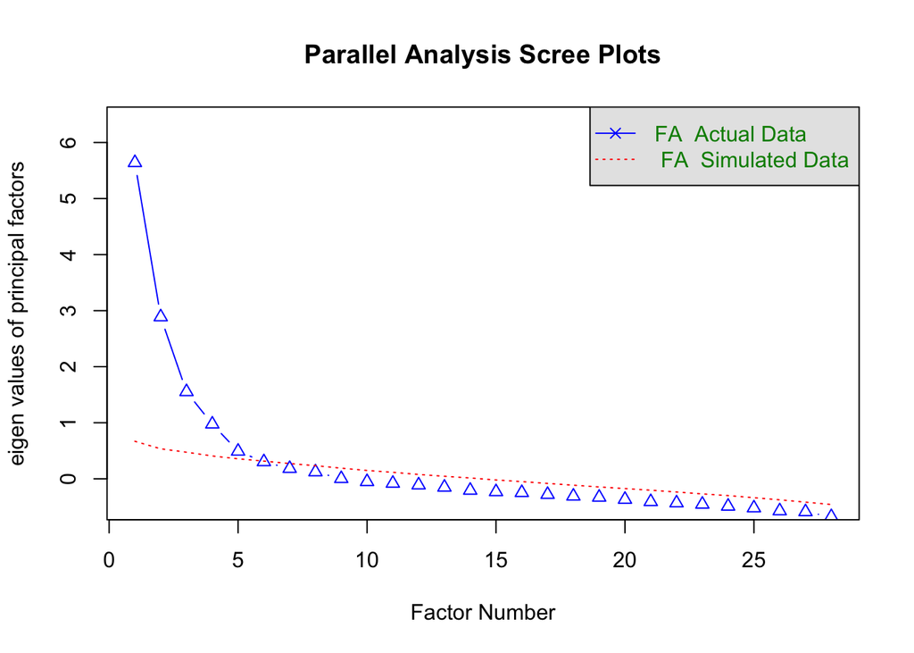

```
## Parallel analysis suggests that the number of factors =  5  and the number of components =  NA
```

```r
#Parallel Analysis
fa.parallel(d2, n.obs = 297, fa='fa')
```

```r
print.psych(fa(d2[1:28], nfactors=6, rotate="varimax",fm="pa"), cut=0.30,sort=TRUE)
```

```
## Factor Analysis using method =  pa
## Call: fa(r = d2[1:28], nfactors = 6, rotate = "varimax", fm = "pa")
## Standardized loadings (pattern matrix) based upon correlation matrix
##     item   PA1   PA2   PA4   PA3   PA5   PA6   h2   u2 com
## X22   22  0.84                               0.73 0.27 1.1
## X25   25  0.77                               0.73 0.27 1.5
## X23   23  0.75                               0.65 0.35 1.3
## X24   24  0.72                               0.61 0.39 1.4
## X21   21  0.53                               0.40 0.60 1.9
## X26   26  0.41                               0.31 0.69 2.8
## X28   28                                     0.22 0.78 3.5
## X12   12        0.75                         0.69 0.31 1.5
## X9     9        0.73                         0.62 0.38 1.3
## X11   11        0.71                         0.51 0.49 1.0
## X8     8        0.70                         0.58 0.42 1.3
## X13   13        0.70                         0.56 0.44 1.3
## X10   10        0.66                         0.49 0.51 1.3
## X17   17              0.73                   0.62 0.38 1.4
## X15   15              0.66                   0.55 0.45 1.5
## X16   16              0.60                   0.43 0.57 1.4
## X14   14              0.48                   0.45 0.55 3.0
## X20   20  0.31        0.43                   0.36 0.64 2.8
## X18   18              0.36  0.32             0.24 0.76 2.1
## X5     5                    0.72             0.54 0.46 1.1
## X4     4                    0.68             0.49 0.51 1.2
## X3     3                    0.58             0.38 0.62 1.3
## X2     2                    0.46             0.41 0.59 2.9
## X1     1                    0.43             0.23 0.77 1.6
## X7     7  0.37        0.32        0.53       0.55 0.45 2.8
## X6     6                          0.48       0.38 0.62 2.4
## X27   27                                0.57 0.48 0.52 2.0
## X19   19  0.31                          0.57 0.46 0.54 1.9
##
##                        PA1  PA2  PA4  PA3  PA5  PA6
## SS loadings           3.60 3.32 2.37 2.18 1.14 1.10
## Proportion Var        0.13 0.12 0.08 0.08 0.04 0.04
## Cumulative Var        0.13 0.25 0.33 0.41 0.45 0.49
## Proportion Explained  0.26 0.24 0.17 0.16 0.08 0.08
## Cumulative Proportion 0.26 0.51 0.68 0.84 0.92 1.00
##
## Mean item complexity =  1.8
## Test of the hypothesis that 6 factors are sufficient.
##
## df null model =  378  with the objective function =  11.75 with Chi Square =  3157.67
## df of  the model are 225  and the objective function was  1.41
##
## The root mean square of the residuals (RMSR) is  0.03
## The df corrected root mean square of the residuals is  0.04
##
## The harmonic n.obs is  280 with the empirical chi square  211.72  with prob <  0.73
## The total n.obs was  280  with Likelihood Chi Square =  374.34  with prob <  0.0000000015
##
## Tucker Lewis Index of factoring reliability =  0.908
## RMSEA index =  0.049  and the 90 % confidence intervals are  0.04 0.057
## BIC =  -893.49
## Fit based upon off diagonal values = 0.98
## Measures of factor score adequacy
##                                                    PA1  PA2  PA4  PA3  PA5  PA6
## Correlation of (regression) scores with factors   0.93 0.94 0.88 0.88 0.80 0.78
## Multiple R square of scores with factors          0.86 0.88 0.77 0.78 0.64 0.61
## Minimum correlation of possible factor scores     0.72 0.75 0.53 0.57 0.28 0.22
```

Step 11: Item Reduction and Re-run Factor Analysis Items were iteratively removed based on low loadings or cross-loadings. After item deletion, parallel analysis suggested 4 factors.

```r
fa(d2[-c(28,20,18,7,19,6,14,21)], rotate="none",fm="pa")$e.values
```

```
##  [1] 4.5737096 3.5602517 2.1426524 1.3946361 0.9833143 0.9550886 0.8671091
##  [8] 0.7511573 0.6160841 0.5586369 0.5265675 0.4955058 0.4392379 0.4099262
## [15] 0.3741823 0.3433038 0.2984446 0.2722510 0.2405699 0.1973712
```

```r
print.psych(fa(d2[-c(28,20,18,7,19,6,14,21)], nfactors=4, rotate="varimax",fm="pa"), cut=0.30,sort=TRUE)
```

```
## Factor Analysis using method =  pa
## Call: fa(r = d2[-c(28, 20, 18, 7, 19, 6, 14, 21)], nfactors = 4, rotate = "varimax",
##     fm = "pa")
## Standardized loadings (pattern matrix) based upon correlation matrix
##     item   PA1   PA2   PA3   PA4   h2   u2 com
## X25   18  0.86                   0.76 0.24 1.0
## X23   16  0.81                   0.67 0.33 1.0
## X22   15  0.75                   0.58 0.42 1.1
## X24   17  0.75                   0.61 0.39 1.2
## X26   19  0.46                   0.28 0.72 1.7
## X27   20  0.42                   0.26 0.74 1.9
## X9     7        0.74             0.59 0.41 1.2
## X12   10        0.73             0.56 0.44 1.1
## X11    9        0.72             0.52 0.48 1.0
## X8     6        0.70             0.50 0.50 1.1
## X13   11        0.68             0.47 0.53 1.0
## X10    8        0.65             0.46 0.54 1.2
## X5     5              0.72       0.55 0.45 1.1
## X4     4              0.62       0.39 0.61 1.0
## X3     3              0.57       0.36 0.64 1.2
## X2     2              0.51       0.36 0.64 1.9
## X1     1              0.45       0.22 0.78 1.2
## X17   14                    0.73 0.61 0.39 1.3
## X15   12                    0.69 0.58 0.42 1.4
## X16   13                    0.56 0.39 0.61 1.5
##
##                        PA1  PA2  PA3  PA4
## SS loadings           3.20 3.12 1.89 1.51
## Proportion Var        0.16 0.16 0.09 0.08
## Cumulative Var        0.16 0.32 0.41 0.49
## Proportion Explained  0.33 0.32 0.19 0.16
## Cumulative Proportion 0.33 0.65 0.84 1.00
##
## Mean item complexity =  1.3
## Test of the hypothesis that 4 factors are sufficient.
##
## df null model =  190  with the objective function =  8.34 with Chi Square =  2264.61
## df of  the model are 116  and the objective function was  1.23
##
## The root mean square of the residuals (RMSR) is  0.04
## The df corrected root mean square of the residuals is  0.05
##
## The harmonic n.obs is  280 with the empirical chi square  191.97  with prob <  0.000012
## The total n.obs was  280  with Likelihood Chi Square =  330.65  with prob <  0.00000000000000000000017
##
## Tucker Lewis Index of factoring reliability =  0.829
## RMSEA index =  0.081  and the 90 % confidence intervals are  0.071 0.092
## BIC =  -322.98
## Fit based upon off diagonal values = 0.97
## Measures of factor score adequacy
##                                                    PA1  PA2  PA3  PA4
## Correlation of (regression) scores with factors   0.94 0.92 0.87 0.85
## Multiple R square of scores with factors          0.88 0.85 0.76 0.72
## Minimum correlation of possible factor scores     0.76 0.71 0.51 0.45
```

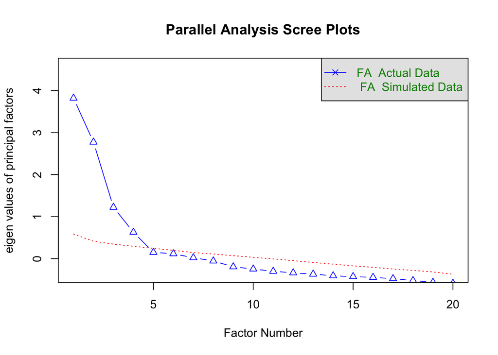

```
## Parallel analysis suggests that the number of factors =  4  and the number of components =  NA
```

```r
fa.parallel(d2[-c(28,20,18,7,19,6,14,21)], n.obs = 297, fa='fa')
```

```r
fa(d2[-c(6,7,8,20)], nfactors=4, rotate="none",fm="pa")$e.values
```

```
##  [1] 5.4369989 3.4845467 2.2511741 1.6317762 1.1006172 0.9960783 0.9459849
##  [8] 0.8277503 0.7379908 0.6753443 0.6605490 0.6130774 0.5550076 0.5312050
## [15] 0.4818190 0.4721017 0.4612856 0.3929566 0.3762770 0.3623083 0.3142824
## [22] 0.2660434 0.2292119 0.1956135
```

```r
print.psych(fa(d2[-c(6,7,8,20)], nfactors=4, rotate="varimax",fm="pa"),cut=0.30, sort=TRUE)
```

```
## Factor Analysis using method =  pa
## Call: fa(r = d2[-c(6, 7, 8, 20)], nfactors = 4, rotate = "varimax",
##     fm = "pa")
## Standardized loadings (pattern matrix) based upon correlation matrix
##     item   PA1   PA2   PA3   PA4   h2   u2 com
## X25   21  0.85                   0.75 0.25 1.1
## X23   19  0.81                   0.67 0.33 1.0
## X22   18  0.76                   0.58 0.42 1.0
## X24   20  0.73                   0.58 0.42 1.2
## X21   17  0.54                   0.38 0.62 1.6
## X26   22  0.45                   0.29 0.71 1.8
## X19   16  0.45                   0.25 0.75 1.5
## X27   23  0.45                   0.29 0.71 1.9
## X28   24  0.32                   0.21 0.79 2.6
## X12    9        0.78             0.63 0.37 1.1
## X13   10        0.74             0.55 0.45 1.0
## X11    8        0.71             0.51 0.49 1.0
## X9     6        0.66             0.51 0.49 1.3
## X10    7        0.62             0.42 0.58 1.2
## X5     5              0.72       0.53 0.47 1.1
## X4     4              0.60       0.37 0.63 1.0
## X3     3              0.58       0.37 0.63 1.2
## X2     2              0.51       0.36 0.64 1.8
## X1     1              0.46       0.23 0.77 1.2
## X17   14                    0.73 0.62 0.38 1.3
## X15   12  0.31              0.68 0.57 0.43 1.5
## X16   13                    0.56 0.38 0.62 1.5
## X14   11  0.31              0.49 0.43 0.57 2.5
## X18   15              0.35  0.36 0.25 0.75 2.0
##
##                        PA1  PA2  PA3  PA4
## SS loadings           3.87 2.77 2.15 1.95
## Proportion Var        0.16 0.12 0.09 0.08
## Cumulative Var        0.16 0.28 0.37 0.45
## Proportion Explained  0.36 0.26 0.20 0.18
## Cumulative Proportion 0.36 0.62 0.82 1.00
##
## Mean item complexity =  1.4
## Test of the hypothesis that 4 factors are sufficient.
##
## df null model =  276  with the objective function =  9.5 with Chi Square =  2566.35
## df of  the model are 186  and the objective function was  1.42
##
## The root mean square of the residuals (RMSR) is  0.04
## The df corrected root mean square of the residuals is  0.05
##
## The harmonic n.obs is  280 with the empirical chi square  251.99  with prob <  0.00091
## The total n.obs was  280  with Likelihood Chi Square =  379.27  with prob <  0.0000000000000025
##
## Tucker Lewis Index of factoring reliability =  0.873
## RMSEA index =  0.061  and the 90 % confidence intervals are  0.052 0.07
## BIC =  -668.8
## Fit based upon off diagonal values = 0.97
## Measures of factor score adequacy
##                                                    PA1  PA2  PA3  PA4
## Correlation of (regression) scores with factors   0.94 0.92 0.88 0.87
## Multiple R square of scores with factors          0.88 0.84 0.77 0.75
## Minimum correlation of possible factor scores     0.77 0.68 0.54 0.51
```

Step 13: Check Internal Consistency Within Each Factor Cronbach’s alpha was calculated to assess internal consistency for each factor.

```r
PA1 <- psych::alpha(d1[c(22,23,24,25,26,27)],use="complete.obs")$total$raw_alpha
PA1
```

```
## [1] 0.8403954
```

```r
PA2 <- psych::alpha(d1[c(8,9,10,11,12,13)],use="complete.obs")$total$raw_alpha
PA2
```

```
## [1] 0.8578377
```

```r
PA3 <- psych::alpha(d1[c(1,2,3,4,5)],use="complete.obs")$total$raw_alpha
PA3
```

```
## [1] 0.728159
```

```r
PA4 <- psych::alpha(d1[c(15,16,17)],use="complete.obs")$total$raw_alpha
PA4
```

```
## [1] 0.7401131
```

Part II: Confirmatory Factor Analysis (CFA) Step 0: Data Preparation

```r
library(lavaan)
options(scipen = 100)
data <- read.csv("~/Desktop/112-2/心測/期末報告/DT_data.csv")
str(data)
```

```
## 'data.frame':    297 obs. of  33 variables:
##  $ ID    : int  1 2 3 4 5 6 7 8 9 10 ...
##  $ School: chr  "HSJH" "HSJH" "HSJH" "HSJH" ...
##  $ Grade : int  8 8 8 8 8 8 8 9 9 9 ...
##  $ Birth : num  99 99 99 98.1 98.1 ...
##  $ Sex   : int  1 1 0 0 1 0 0 1 1 1 ...
##  $ X1    : int  6 4 4 4 6 4 3 6 3 6 ...
##  $ X2    : int  1 3 6 6 4 4 4 4 2 4 ...
##  $ X3    : int  3 3 5 4 6 4 4 5 5 3 ...
##  $ X4    : int  5 4 6 4 4 4 4 5 5 4 ...
##  $ X5    : int  4 3 5 4 6 4 4 5 5 5 ...
##  $ X6    : int  2 3 4 4 4 4 3 2 3 4 ...
##  $ X7    : int  1 3 1 3 5 3 4 1 1 4 ...
##  $ X8    : int  1 3 1 3 1 4 3 4 1 1 ...
##  $ X9    : int  1 3 4 3 1 4 4 5 1 3 ...
```

[output cut: 19 more lines]

Step 1: Use Modification Indices to Improve Model Fit Model 1 (m1): Initial model using all items showed poor fit: χ²(318) = 1090.98, p < .001; CFI = .73, RMSEA = .09, SRMR = .12

```r
m1  <- 'f1 =~ X1+ X2+ X3+ X4+ X5+ X6+ X7
        f2 =~ X8+ X9+ X10+ X11+ X12+ X13+ X14
        f3 =~ X15+ X16+ X17+ X19+ X20+ X21
        f4 =~ X22+ X23+ X24+ X25+ X26+ X27+ X28'
fitm1 <- cfa(m1, data=data)
summary(fitm1, fit.measures=TRUE, standardized=TRUE, rsquare=T)
```

```
## lavaan 0.6-19 ended normally after 54 iterations
##
##   Estimator                                         ML
##   Optimization method                           NLMINB
##   Number of model parameters                        60
##
##                                                   Used       Total
##   Number of observations                           281         297
##
## Model Test User Model:
##
##   Test statistic                              1090.981
##   Degrees of freedom                               318
##   P-value (Chi-square)                           0.000
##
## Model Test Baseline Model:
##
##   Test statistic                              3216.327
##   Degrees of freedom                               351
##   P-value                                        0.000
##
## User Model versus Baseline Model:
##
##   Comparative Fit Index (CFI)                    0.730
##   Tucker-Lewis Index (TLI)                       0.702
##
## Loglikelihood and Information Criteria:
##
##   Loglikelihood user model (H0)             -12187.249
##   Loglikelihood unrestricted model (H1)     -11641.758
##
##   Akaike (AIC)                               24494.498
##   Bayesian (BIC)                             24712.799
##   Sample-size adjusted Bayesian (SABIC)      24522.541
##
## Root Mean Square Error of Approximation:
##
##   RMSEA                                          0.093
##   90 Percent confidence interval - lower         0.087
##   90 Percent confidence interval - upper         0.099
```

[output cut: 107 more lines]

```
##     X13               0.478
##     X14               0.137
##     X15               0.499
##     X16               0.256
##     X17               0.498
##     X19               0.241
##     X20               0.330
##     X21               0.220
##     X22               0.603
##     X23               0.697
##     X24               0.553
##     X25               0.760
##     X26               0.216
##     X27               0.191
##     X28               0.088
```

```r
sl1 <- standardizedSolution(fitm1) #standardized result
modificationIndices(fitm1, minimum.value = 10)
```

```
##     lhs op rhs     mi    epc sepc.lv sepc.all sepc.nox
## 82   f1 =~ X26 19.676  0.631   0.480    0.288    0.288
## 84   f1 =~ X28 26.940  0.878   0.668    0.359    0.359
## 104  f2 =~ X28 13.991  0.441   0.431    0.232    0.232
## 107  f3 =~  X3 13.374 -0.302  -0.326   -0.251   -0.251
## 108  f3 =~  X4 15.561 -0.322  -0.348   -0.267   -0.267
## 110  f3 =~  X6 19.403  0.380   0.410    0.302    0.302
## 111  f3 =~  X7 50.151  0.689   0.744    0.480    0.480
## 118  f3 =~ X14 72.713  0.665   0.718    0.566    0.566
## 128  f4 =~  X3 19.676 -0.302  -0.356   -0.275   -0.275
## 129  f4 =~  X4 10.708 -0.220  -0.260   -0.200   -0.200
## 130  f4 =~  X5 18.771 -0.281  -0.331   -0.262   -0.262
## 131  f4 =~  X6 26.793  0.369   0.435    0.320    0.320
## 132  f4 =~  X7 50.835  0.572   0.675    0.436    0.436
## 139  f4 =~ X14 39.910  0.404   0.477    0.376    0.376
```

[output cut: 33 more lines]

Items were removed based on the factor loading (λ), R-squared, and Modification Index (MI).

Model 6 (m6): Final model after item removal showed good fit: χ²(113) = 197.99, p < .001; CFI = .95, RMSEA = .05, SRMR = .06

```r
m6  <- 'f1 =~ X1+ X3+ X4+ X5
        f2 =~ X8+ X9+ X10+ X11+ X13
        f3 =~ X15+ X16+ X17
        f4 =~ X22+ X23+ X24+ X25+ X26'
fitm6 <- cfa(m6, data=data)
summary(fitm6, fit.measures=TRUE, standardized=TRUE, rsquare=T)
```

```
## lavaan 0.6-19 ended normally after 49 iterations
##
##   Estimator                                         ML
##   Optimization method                           NLMINB
##   Number of model parameters                        40
##
##                                                   Used       Total
##   Number of observations                           285         297
##
## Model Test User Model:
##
##   Test statistic                               197.985
##   Degrees of freedom                               113
##   P-value (Chi-square)                           0.000
##
## Model Test Baseline Model:
##
##   Test statistic                              1881.417
##   Degrees of freedom                               136
##   P-value                                        0.000
##
## User Model versus Baseline Model:
##
##   Comparative Fit Index (CFI)                    0.951
##   Tucker-Lewis Index (TLI)                       0.941
##
## Loglikelihood and Information Criteria:
##
##   Loglikelihood user model (H0)              -7682.145
##   Loglikelihood unrestricted model (H1)      -7583.153
##
##   Akaike (AIC)                               15444.291
##   Bayesian (BIC)                             15590.390
##   Sample-size adjusted Bayesian (SABIC)      15463.548
##
## Root Mean Square Error of Approximation:
##
##   RMSEA                                          0.051
##   90 Percent confidence interval - lower         0.039
##   90 Percent confidence interval - upper         0.063
```

[output cut: 77 more lines]

```
##     X4                0.380
##     X5                0.639
##     X8                0.596
##     X9                0.685
##     X10               0.501
##     X11               0.413
##     X13               0.343
##     X15               0.585
##     X16               0.323
##     X17               0.612
##     X22               0.632
##     X23               0.706
##     X24               0.569
##     X25               0.761
##     X26               0.217
```

```r
sl6 <- standardizedSolution(fitm6) #standardized result
sl6
```

```
##    lhs op rhs est.std    se      z pvalue ci.lower ci.upper
## 1   f1 =~  X1   0.363 0.061  5.947  0.000    0.243    0.482
## 2   f1 =~  X3   0.618 0.050 12.245  0.000    0.519    0.717
## 3   f1 =~  X4   0.616 0.051 12.197  0.000    0.517    0.715
## 4   f1 =~  X5   0.800 0.048 16.809  0.000    0.706    0.893
## 5   f2 =~  X8   0.772 0.031 24.679  0.000    0.710    0.833
## 6   f2 =~  X9   0.828 0.028 30.017  0.000    0.774    0.882
## 7   f2 =~ X10   0.708 0.036 19.761  0.000    0.638    0.778
## 8   f2 =~ X11   0.642 0.041 15.847  0.000    0.563    0.722
## 9   f2 =~ X13   0.586 0.044 13.204  0.000    0.499    0.673
## 10  f3 =~ X15   0.765 0.041 18.771  0.000    0.685    0.845
## 11  f3 =~ X16   0.569 0.049 11.582  0.000    0.472    0.665
## 12  f3 =~ X17   0.782 0.040 19.429  0.000    0.704    0.861
## 13  f4 =~ X22   0.795 0.026 30.489  0.000    0.744    0.846
## 14  f4 =~ X23   0.840 0.022 37.556  0.000    0.796    0.884
```

[output cut: 30 more lines]

```r
modificationIndices(fitm6, minimum.value = 10)
```

```
##     lhs op rhs     mi   epc sepc.lv sepc.all sepc.nox
## 51   f1 =~ X16 15.374 0.589   0.322    0.236    0.236
## 187 X11 ~~ X13 11.384 0.288   0.288    0.229    0.229
## 227 X23 ~~ X25 21.336 0.310   0.310    0.583    0.583
## 230 X24 ~~ X26 11.405 0.279   0.279    0.222    0.222
```

Step 2: Plot Final CFA Structure A diagram of the final CFA model was generated to visually present factor-item relationships.

```r
library(semPlot)
getwd()# check the working directory
```

```
## [1] "/Users/zhengjingyi/Desktop/IT/統計"
```

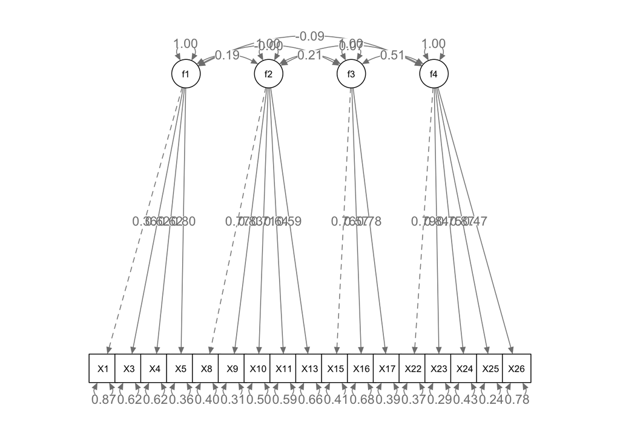

```r
semPaths(fitm6,               #object generated by cfa()
         what = "path",          # Type of diagram to plot
         whatLabels = "std",     # Standardized estimates
         style = "ram",         # Style of the diagram; "ram"
         layout = "tree",        # Layout of the diagram
         edge.label.cex = 1,     # Size of edge labels
         nCharNodes = 5,         # Number of characters per node
         sizeMan = 5,           # Size of manifest variables
         sizeLat = 5)           # Size of latent variables
```